# Computer Vision Project

## PART A

University X is currently undergoing some research involving understanding the characteristics of plant and plant seedlings at various stages of growth. They already have have invested on curating sample images. They require an automation which can create a classifier capable of determining a plant's species from a photo.

**Importing modules for project**

```python
import pandas as pd
import numpy as np
import seaborn as sns
import matplotlib.pyplot as plt
from matplotlib.image import imread
import os
import tensorflow as tf
tf.__version__
from sklearn.metrics import classification_report,confusion_matrix
from sklearn.model_selection import train_test_split
from scipy import stats

from sklearn import metrics
from sklearn.linear_model import LogisticRegression
from keras.preprocessing.image import ImageDataGenerator
import cv2
from sklearn.metrics import classification_report,confusion_matrix
from sklearn.metrics import accuracy_score
from sklearn.naive_bayes import GaussianNB

%matplotlib inline

import warnings
warnings.filterwarnings("ignore")
```

**Extract ‘plant-seedlings-classification.zip’ into new folder (unzipped) using python**

```python
from zipfile import ZipFile
# Create a ZipFile Object and load sample.zip in it
with ZipFile('plant-seedlings-classification.zip', 'r') as zipObj:
   # Extract all the contents of zip file in current directory
   zipObj.extractall()
```

extracted in current directory.

**Map the images from train folder with train labels to form a DataFrame**

```python
labels = ['Black-grass', 'Charlock','Cleavers','Common Chickweed','Common Wheat','Fat Hen','Loose Silky-bent','Maize','Scentless Mayweed','Shepherds Purse','Small-flowered Cranesbill','Sugar beet']
img_size = 224
def get_data(data_dir):
    data = []
    for label in labels:
        path = os.path.join(data_dir, label)
        class_num = labels.index(label)
        for img in os.listdir(path):
            try:
                img_arr = cv2.imread(os.path.join(path, img),cv2.IMREAD_GRAYSCALE) #convert BGR to RGB format
                resized_arr = cv2.resize(img_arr, (img_size, img_size)) # Reshaping images to preferred size
                data.append([resized_arr, class_num])
            except Exception as e:
                print(e)
    return np.array(data)
```

```python
train = get_data('E:/pgpaiml/project/com vis project/plant-seedlings-classification/train')
```

```python
train
```

[output not shown]

```python
l = []
for i in train:
    if(i[1] == 0):
        l.append("Black-grass")
    elif(i[1]==1):
        l.append("Charlock")
    elif(i[1]==2):
        l.append("Cleavers")
    elif(i[1]==3):
        l.append("Common Chickweed")
    elif(i[1]==4):
        l.append("Common Wheat")
    elif(i[1]==5):
        l.append("Fat Hen")
    elif(i[1]==6):
        l.append("Loose Silky-bent")
    elif(i[1]==7):
        l.append("Maize")
    elif(i[1]==8):
        l.append("Scentless Mayweed")
    elif(i[1]==9):
        l.append("Shepherds Purse")
    elif(i[1]==10):
        l.append("Small-flowered Cranesbill")
    else:
        l.append("Sugar beet")
```

```python
t=pd.DataFrame(train,columns= ['Image','Label'])
```

```python
t['Label']=l
```

```python
t
```

|  | Image | Label |
| --- | --- | --- |
| 0 | [[56, 49, 57, 66, 72, 77, 85, 91, 89, 90, 89, ... | Black-grass |
| 1 | [[46, 48, 55, 53, 57, 58, 66, 84, 106, 112, 10... | Black-grass |
| 2 | [[30, 34, 41, 34, 37, 42, 53, 50, 51, 51, 57, ... | Black-grass |
| 3 | [[87, 88, 91, 91, 90, 90, 91, 91, 91, 91, 92, ... | Black-grass |
| 4 | [[163, 161, 163, 162, 156, 166, 163, 162, 159,... | Black-grass |
| ... | ... | ... |
| 4745 | [[90, 76, 79, 76, 89, 151, 160, 157, 159, 123,... | Sugar beet |
| 4746 | [[68, 71, 70, 64, 55, 48, 52, 58, 60, 58, 58, ... | Sugar beet |
| 4747 | [[61, 64, 69, 63, 65, 63, 60, 58, 54, 52, 67, ... | Sugar beet |
| 4748 | [[144, 145, 149, 147, 148, 151, 150, 143, 148,... | Sugar beet |
| 4749 | [[87, 84, 90, 94, 90, 94, 92, 90, 84, 70, 54, ... | Sugar beet |

4750 rows × 2 columns

**Write a function that will select n random images and display images along with its species.**

```python
# visualizing the random images in the dataset along with their labels
def dis(num):
    rand = np.random.randint(0, len(train), num)
    print(rand)
    rows = len(rand)/2
    columns = len(rand)/4
    j=0
    plt.figure(figsize=(10,10))
    for i in rand :
        plt.subplot(rows, columns, j+1)
        plt.imshow(train[i][0])
        plt.title(labels[train[i][1]])
        plt.axis('off')
        j=j+1
    plt.show()
```

```
[1899 1458 3833  808  648   28 4347 1103 1211 1422]
```

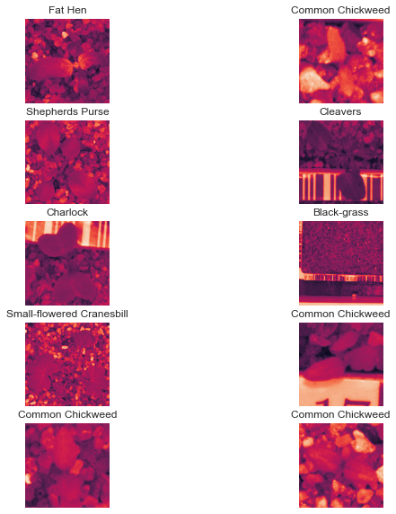

```python
dis(10)
```

**Create X & Y from the DataFrame**

```python
X=t["Image"]
Y=t["Label"]
```

```python
print("Total no of images :",len(X))
print("Total no of labels :",len(Y))
```

```
Total no of images : 4750
Total no of labels : 4750
```

**Encode labels of the images.**

```python
from sklearn import preprocessing

# label_encoder object knows how to understand word labels.
label_encoder = preprocessing.LabelEncoder()

# Encode labels in column 'species'.
t["Label"]= label_encoder.fit_transform(t["Label"])

t["Label"].unique()
```

```
array([ 0,  1,  2,  3,  4,  5,  6,  7,  8,  9, 10, 11])
```

```python
Y=t["Label"]
```

```python
Y[3369]
```

```
8
```

```python
X[450]
```

```
array([[188, 188, 188, ...,  52,  54,  53],
       [187, 187, 188, ...,  54,  53,  51],
       [186, 185, 183, ...,  55,  54,  53],
       ...,
       [ 60,  60,  52, ...,  88,  87,  87],
       [ 57,  55,  51, ...,  85,  89,  92],
       [ 51,  46,  49, ...,  91,  99, 100]], dtype=uint8)
```

**Unify shape of all the images**

```python
x_train_resized=np.zeros((X.shape[0],50,50))
for i in range(X.shape[0]):
  #using cv2.resize to resize each train example to 28X28 size using Cubic interpolation
  x_train_resized[i,:,:]=cv2.resize(X[i],dsize=(50,50),interpolation=cv2.INTER_CUBIC)
X = x_train_resized.reshape(x_train_resized.shape[0], 50, 50, 1)
```

**Normalise all the images.**

```python
X = X.astype('float32')

X /= 255
```

**Split the data into train and test data.**

```python
X_train, X_test, y_train, y_test = train_test_split(X,Y, test_size=0.30, random_state=1)
```

**Create new CNN architecture to train the model.**